```python
%%html
<!--Script block to left align Markdown Tables-->
<style>
  table {margin-left: 0 !important;}
</style>
```

# ENGR 1330 Computational Thinking with Data Science

Last GitHub Commit Date: 4 Nov 2021

## Lesson 20 : Assess Regression-Based Prediction Engines

Procedures to judge our prediction engine.

## Objectives

- Create goodness-of-fit metrics
- Create interval estimates of parameters (slope, intercept, ...)
- Create interval estimates of predictions

## Computational Thinking Concepts

| Description | Computational Thinking Concept |
| --- | --- |
| Linear Model | Abstraction |
| Response and Explanatory Variables | Decomposition |
| Primitive arrays: vectors and matrices | Data Representation |
| NumPy arrays: vectors and matrices | Data Representation |

## Textbook Resources

https://inferentialthinking.com/chapters/15/Prediction.html

## Useful Terminology from a Marksmanship Analog

Pretend we are working on a FPS game named "Olympic 10-meter Air Pistol" we are developing as a training tool. https://en.wikipedia.org/wiki/ISSF_10_meter_air_pistol

First some packages

```python
import random
import numpy
import matplotlib.pyplot
```

So first we are going to build a function that shows a target, with strikes on the target.

```python
def showmytarget(myx,myy,centerx,centery):
#    import matplotlib.pyplot as plt
    fig, ax = matplotlib.pyplot.subplots(figsize = (10,10)) # note we must use plt.subplots, not plt.subplot
    circle1 = matplotlib.pyplot.Circle((centerx, centery), 1, color='black')
    circle2 = matplotlib.pyplot.Circle((centerx, centery), 1, color='orange', fill=False)
    circle3 = matplotlib.pyplot.Circle((centerx, centery), 0.5, color='orange', fill=False)
    circle4 = matplotlib.pyplot.Circle((centerx, centery), 2, color='black', fill=False)
    circle5 = matplotlib.pyplot.Circle((centerx, centery), 3, color='black', fill=False)
    circle6 = matplotlib.pyplot.Circle((centerx, centery), 4, color='black', fill=False)
    circle7 = matplotlib.pyplot.Circle((centerx, centery), 5, color='black', fill=False)
    circle8 = matplotlib.pyplot.Circle((centerx, centery), 6, color='black', fill=False)
    ax.set_xlim((-10, 10))
    ax.set_ylim((-10, 10))
    ax.plot(myx,myy, 'o', color='r') #vector of hits
    ax.add_artist(circle1)
    ax.add_artist(circle2)
    ax.add_artist(circle3)
    ax.add_artist(circle4)
    ax.add_artist(circle5)
    ax.add_artist(circle6)
    ax.add_artist(circle7)
    ax.add_artist(circle8)
    matplotlib.pyplot.show()
    return
```

### Accuracy

The concept of accuracy is a measure of how close to the "true" or population value is our estimate.  
If we are estimating the mean value, then the "bullseye" is the population mean $\mu$, our estimate is $\bar x$.

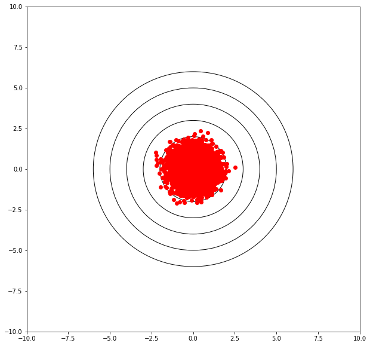

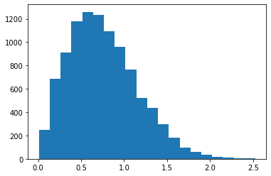

```
mean distance from bullseye = 0.7551023150985438
```

```python
mu = 0.0 # where we tend to hit
sigma = 0.60 # how steady we are when the shot trips
myx = []; myy = []; distxy = []
for i in range(10001): # 10000 shots
    xvalue = random.gauss(mu, sigma)
    yvalue = random.gauss(mu, sigma)
    myx.append(xvalue)
    myy.append(yvalue)
    distxy.append((xvalue**2 + yvalue**2)**0.5)
showmytarget(myx,myy,0,0)
matplotlib.pyplot.hist(distxy,bins=20)
matplotlib.pyplot.show()
print('mean distance from bullseye =',numpy.mean(distxy))
```

# Aiming Point

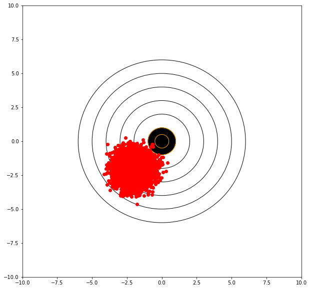

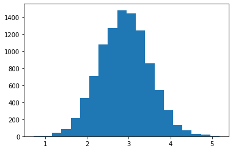

```
mean distance from bullseye = 2.8941689277114375
```

```python
mu = -2.0 # where we tend to hit
sigma = 0.6 # how steady we are when the shot trips
myx = []; myy = []; distxy = []
for i in range(10001): # 10 shots
    xvalue = random.gauss(mu, sigma)
    yvalue = random.gauss(mu, sigma)
    myx.append(xvalue)
    myy.append(yvalue)
    distxy.append((xvalue**2 + yvalue**2)**0.5)
showmytarget(myx,myy,0,0)
matplotlib.pyplot.hist(distxy,bins=20)
matplotlib.pyplot.show()
print('mean distance from bullseye =',numpy.mean(distxy))
```

### Precision

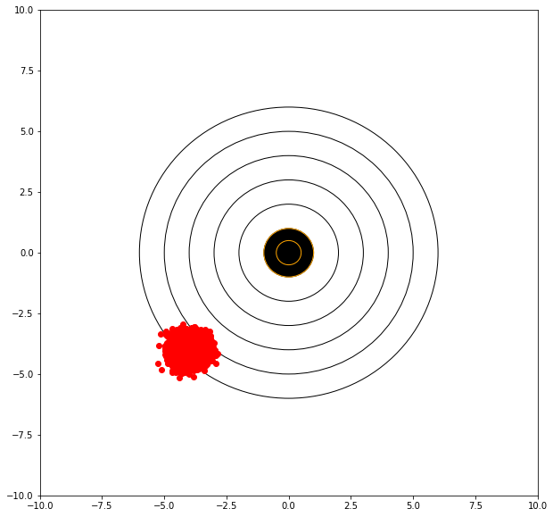

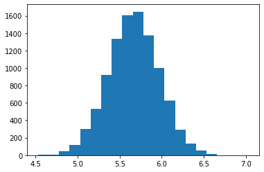

```
mean distance from bullseye = 5.665993316640305
```

```python
mu = -4.0 # where we tend to hit
sigma = 0.3 # how steady we are when the shot trips
myx = []; myy = []; distxy = []
for i in range(10001): # 10 shots
    xvalue = random.gauss(mu, sigma)
    yvalue = random.gauss(mu, sigma)
    myx.append(xvalue)
    myy.append(yvalue)
    distxy.append((xvalue**2 + yvalue**2)**0.5)
showmytarget(myx,myy,0,0)
matplotlib.pyplot.hist(distxy,bins=20)
matplotlib.pyplot.show()
print('mean distance from bullseye =',numpy.mean(distxy))
```

If we can adjust our sights to hit a bit high and right (of the red dots) then we anticipate a better score.

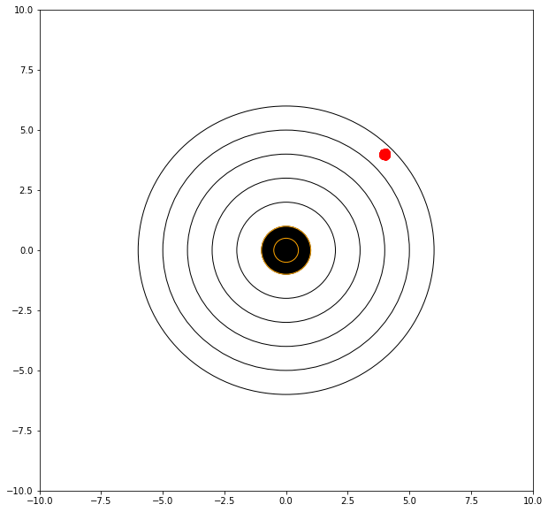

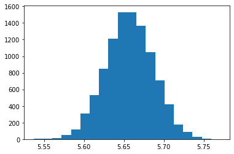

```
mean distance from bullseye = 5.656902120931369
```

```python
mu = 4.00 # where we tend to hit
sigma = 0.03 # how steady we are when the shot trips
myx = []; myy = []; distxy = []
for i in range(10001): # 10 shots
    xvalue = random.gauss(mu, sigma)
    yvalue = random.gauss(mu, sigma)
    myx.append(xvalue)
    myy.append(yvalue)
    distxy.append((xvalue**2 + yvalue**2)**0.5)
showmytarget(myx,myy,0,0)
matplotlib.pyplot.hist(distxy,bins=20)
matplotlib.pyplot.show()
print('mean distance from bullseye =',numpy.mean(distxy))
```

### Bias

Bias is a systematic "error" or offset - similar to the distance from the bullseye in our examples. If we have a precise rifle that shoots a known distance from the bullseye, thats still a useful tool - we either adjust our aiming point, or the device to account for this bias. Its akin to the last example where we demonstrate the contribution to error from a poor point of aim, and an unsteady hand.

## Residuals

In the context of our target shooting, the residual is the distance from the target that our model (the rifle) places the estimate (shot). Lets examine the simulations over again. First with a bias and unsteady hands

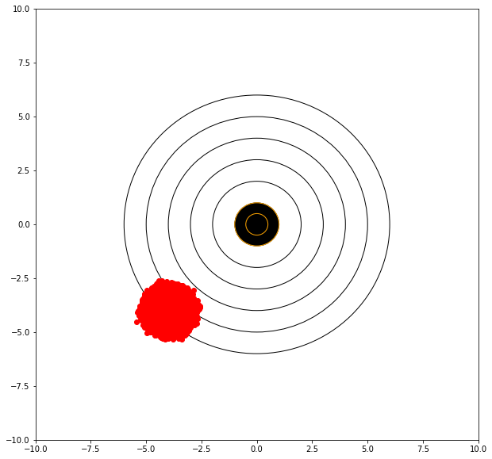

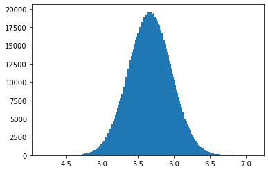

```
mean distance from bullseye = 5.6649390505895
```

```python
mu = -4.0 # where we tend to hit
sigma = 0.3 # how steady we are when the shot trips
myx = []; myy = []; distxy = []
for i in range(1000001): # 10 shots
    xvalue = random.gauss(mu, sigma)
    yvalue = random.gauss(mu, sigma)
    myx.append(xvalue)
    myy.append(yvalue)
    distxy.append((xvalue**2 + yvalue**2)**0.5)
showmytarget(myx,myy,0,0)
matplotlib.pyplot.hist(distxy,bins=200)
matplotlib.pyplot.show()
print('mean distance from bullseye =',numpy.mean(distxy))
```

In these examples we know the target should be at (0,0) so lets stipulate that to our model (rifle).

[figure not shown]

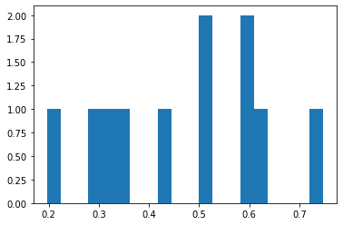

```
mean distance from bullseye = 0.46869751485834743
mean dispersion from point of aim = 0.15840957008535536
```

```python
mu = 0.0 # where we tend to hit
sigma = 0.3 # how steady we are when the shot trips
myx = []; myy = []; distxy = []
for i in range(11): # 10 shots
    xvalue = random.gauss(mu, sigma)
    yvalue = random.gauss(mu, sigma)
    myx.append(xvalue)
    myy.append(yvalue)
    distxy.append((xvalue**2 + yvalue**2)**0.5)
showmytarget(myx,myy,0,0)
matplotlib.pyplot.hist(distxy,bins=20)
matplotlib.pyplot.show()
print('mean distance from bullseye =',numpy.mean(distxy))
print('mean dispersion from point of aim =',numpy.std(distxy))
```

Now lets improve our situatuon by putting our device into a mechanical mount that reduces the shake.

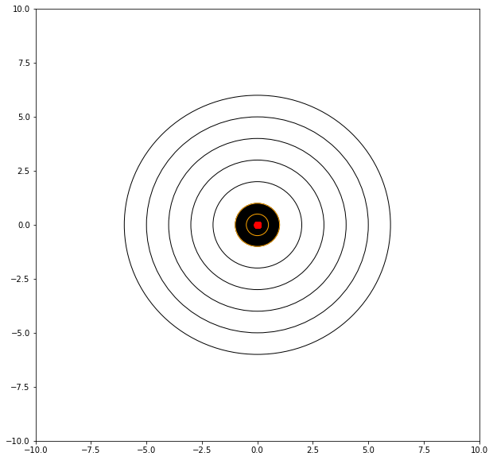

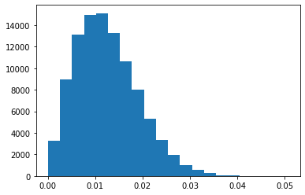

```
mean distance from bullseye = 0.012527979281636773
mean dispersion from point of aim = 0.006536297973942887
```

```python
mu = 0.0 # where we tend to hit
sigma = 0.01 # how steady we are when the shot trips
myx = []; myy = []; distxy = []
for i in range(100001): # 10 shots
    xvalue = random.gauss(mu, sigma)
    yvalue = random.gauss(mu, sigma)
    myx.append(xvalue)
    myy.append(yvalue)
    distxy.append((xvalue**2 + yvalue**2)**0.5)
showmytarget(myx,myy,0,0)
matplotlib.pyplot.hist(distxy,bins=20)
matplotlib.pyplot.show()
print('mean distance from bullseye =',numpy.mean(distxy))
print('mean dispersion from point of aim =',numpy.std(distxy))
```

A technique you will learn in your statistics class called analysis of variance is a practical application of these ideas. The distances (in this case always positive) are the residuals, and the variance has two contributing components; how far from the true value the estimator is (our bullseye distance); and how spread out around the point of aim the estimates are (sample variance).

What adds to the challenge is what happens when the target moves!

```python
mu = -3.40 # where we tend to hit
sigma = 0.01 # how steady we are when the shot trips
myx = []; myy = []; distxy = []
for i in range(1001): # 10 shots
    xvalue = random.gauss(mu, sigma)
    yvalue = random.gauss(mu, sigma)
    myx.append(xvalue)
    myy.append(yvalue)
    distxy.append(((xvalue+1)**2 + (yvalue+3)**2)**0.5)
showmytarget(myx,myy,-1,-3)
matplotlib.pyplot.hist(distxy,bins=20)
matplotlib.pyplot.show()
print('mean distance from bullseye =',numpy.mean(distxy))
print('mean dispersion from point of aim =',numpy.std(distxy))
```

[output not shown]

## Linear Regression

A predictive analytics technique that uses historical (either a temporal sense, or just actual observation is implied) data to predict an output variable.

#### Why do we employ linear regression?

To explore the relationship between predictor and output variables and predict the output variable based on known values of predictors.

#### How does linear regression work?

To estimate Y using linear regression, we stipulate the model equation: $Y_e=\beta X + \alpha$

The goal is to find statistically significant values of the parameters $\alpha$ and $\beta$ that minimise the difference between $Y_{obs}$ and $Y_e$. If we are able to determine the optimum values of these two parameters, then we will have the line of best fit that we can use to predict the values of $Y$, given the value of $X$.

#### How to estimate the coefficients?

We used a method called "Ordinary Least Squares (OLS)" and minimized the error term (using calculus) as

$\epsilon=Y_{obs} - (\beta X + \alpha)$ and found that the unknown values for $\alpha$ and $\beta$ were related to the covariance of X and Y and the variance of X. We constructed nomral equations, and developed a systematic method to estimate the parameters $\alpha$ and $\beta$.

For grins, we did this using primative python and linear algebra, and again using external packages.

Now remember when we discussed Probability Density Function (PDF) for the normal distribution? - Probably not!

[figure not shown]

This equation is telling us the probability density of our sample x from our random variable generator X, when the true parameters of the distribution are μ and σ. If the density is kind of large (these are always small numbers, less than one) we would infer that the value is common, frequent, likely ...

Let’s say our value is 3, what is the probability it comes from a distribution of μ = 3 and σ = 1? What if it came from a distribution with μ = 7 and σ = 2? Which one is more probable?

```python
import numpy as np
import pandas as pd
import statistics
import scipy.stats
from matplotlib import pyplot as plt
```

```python
scipy.stats.norm.pdf(3, 3, 1)
```

```
0.3989422804014327
```

```python
scipy.stats.norm.pdf(3, 7, 2)
```

```
0.02699548325659403
```

So it is much more likely it came from the first distribution. The PDF equation has shown us how likely those values are to appear in a distribution with certain parameters. Keep that in mind for later. But what if we had a bunch of points we wanted to estimate?

Let’s assume we get a bunch of samples from our process generator X which we know to come from some normal distribution, and all are mutually independent from each other. If this is the case, the total probability of observing all of the data is the product of obtaining each data point individually.

What is the probability of 2 and 6 being drawn from a distribution with μ = 4 and σ = 1

```python
scipy.stats.norm.pdf(2, 4, 1) * scipy.stats.norm.pdf(6, 4, 1)
```

```
0.0029150244650281948
```

## Maximum Likelihood Estimation (MLE)

A method used to specify a distribution of unknown parameters, then using your data to pull out the actual parameter values. Let's look at our linear model:

[figure not shown]

The noise parameter (error) is basically why the points (samples) do not fall exactly on the line. The error for each point would be the distance from the point to our line. We’d like to explicitly include those errors in our model. One method of doing this, is to **assume** the errors are distributed from a Gaussian (Normal) distribution with a mean of 0 and some unknown variance σ². The Gaussian seems like a good choice, because our errors look like they’re symmetric about were the line would be, and that small errors are more likely than large errors.

This model actually has *three* parameters: the slope and intercept of our line and the variance of the noise distribution. Our main goal is to find the best parameters for the slope and intercept of our line.

let’s rewrite our model from above as a single conditional distribution given x:

[figure not shown]

This is equivalent to pushing our x through the equation of the line and then adding noise from the 0 mean Gaussian. Now, we can write the conditional distribution of y given x in terms of this Gaussian. This is just the equation of a Gaussian distribution’s probability density function, with our linear equation in place of the mean:

[figure not shown]

The semicolon in the conditional distribution is just like a comma, but it’s a useful notation for separating our observed data from the parameters.

Each point is independent and identically distributed (iid), so we can write the likelihood function with respect to all of our observed points as the product of each individual probability density. Since σ² is the same for each data point, we can factor out the term of the Gaussian which doesn’t include x or y from the product:

[figure not shown]

The next step in MLE, is to find the parameters which maximize this function. To make our equation simpler, let’s take the log of our likelihood. Recall, that maximizing the log-likelihood is the same as maximizing the likelihood since the log is monotonic. The natural log cancels out with the exponential, turns products into sums of logs, and division into subtraction of logs; so our log-likelihood looks much simpler:

[figure not shown]

To clean things up a bit more, let’s write the output of our line as a single value:

[figure not shown]

Now our log-likelihood can be written as:

[figure not shown]

To remove the negative signs, let’s recall that maximizing a number is the same thing as minimizing the negative of the number. So instead of maximizing the likelihood, let’s minimize the negative log-likelihood:

[figure not shown]

Our ultimate goal is to find the parameters of our line. To minimize the negative log-likelihood with respect to the linear parameters (the θs), we can imagine that our variance term is a fixed constant. Removing any constant’s which don’t include our θs won’t alter the solution. Therefore, we can throw out any constant terms and elegantly write what we’re trying to minimize as:

[figure not shown]

The maximum likelihood estimate for our linear model is the line which minimizes the sum of squared errors!

[figure not shown]

Now, let's solve for parameters. We’ve concluded that the maximum likelihood estimates for our slope and intercept can be found by minimizing the sum of squared errors. Let’s expand out our minimization objective and use i as our index over our n data points:

[figure not shown]

The square in the SSE formula makes it quadratic with a single minimum. The minimum can be found by taking the derivative with respect to each of the parameters, setting it equal to 0, and solving for the parameters in turn.

Taking the partial derivative with respect to the intercept, Setting the derivative equal to 0 and solving for the intercept gives us:

[figure not shown]

Taking the partial derivative with respect to the slope, Setting the derivative equal to 0 and solving for the slope gives us:

[figure not shown]

#### And now it's time to put it all together:

```python
def find_line(xs, ys):
    """Calculates the slope and intercept"""

    # number of points
    n = len(xs)
    # calculate means
    x_bar = sum(xs)/n
    y_bar = sum(ys)/n

    # calculate slope
    num = 0
    denom = 0
    for i in range(n):
        num += (xs[i]-x_bar)*(ys[i]-y_bar)
        denom += (xs[i]-x_bar)**2
    slope = num/denom

    # calculate intercept
    intercept = y_bar - slope*x_bar

    return slope, intercept
```

### Example

Let's have a look at the missle telemetry in the previous lab!

We had a table of recorded times and speeds from some experimental observations. Use MLE to find the intercept and the slope:

[output not shown]

```python
time = [0, 1.0, 2.0, 3.0, 4.0, 5.0, 6.0, 7.0, 8.0, 9.0, 10.0]
speed = [0, 3, 7, 12, 20, 30, 45.6, 60.3, 77.7, 97.3, 121.2]
find_line(time, speed) #Is this similar to our past results?!
```

```
(11.977272727272727, -16.78636363636364)
```

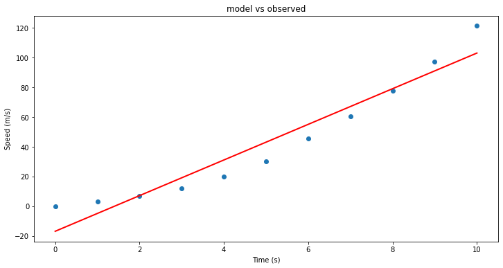

```python
# Predict values
X = np.array(time)
alpha = -16.78636363636364
beta = 11.977272727272727
ypred = alpha + beta * X


# Plot regression against actual data
plt.figure(figsize=(12, 6))
plt.plot(X, speed, 'o')           # scatter plot showing actual data
plt.plot(X, ypred, 'r', linewidth=2)   # regression line
plt.xlabel('Time (s)')
plt.ylabel('Speed (m/s)')
plt.title('model vs observed')

plt.show()
```

## Goodness-of-Fit

So far, we have assessed the quality of fits visually. We can make numerical assessments as well via Goodness-of-Fit (GOF) measures. Let's discuss three of the most common metrics for evaluating predictions on regression machine learning problems:

#### Mean Absolute Error (MAE):

The Mean Absolute Error (or MAE) is the average of the absolute differences between predictions and actual values. It gives an idea of how wrong the predictions were. The measure gives an idea of the magnitude of the error, but no idea of the direction (e.g. over or under predicting). Here is the formula:

[figure not shown]

It is thus an arithmetic average of the absolute errors $|e_i|=|y_i-x_i|$, where $y_i$ is the prediction and $x_i$ the true value. This is known as a scale-dependent accuracy measure and therefore cannot be used to make comparisons between series using different scales.

```python
# calculate manually
d = speed - ypred
mae_m = np.mean(abs(d))


print("Results by manual calculation:")
print("MAE:",mae_m)



import sklearn.metrics as metrics
mae = metrics.mean_absolute_error(speed, ypred)
print(mae)
```

```
Results by manual calculation:
MAE: 8.927272727272728
8.927272727272728
```

### Mean Squared Error (MSE) and Root Mean Squared Error (RMSE):

The Mean Squared Error (or MSE) is much like the mean absolute error in that it provides a gross idea of the magnitude of error. It measures the average of the squares of the errors—that is, the average squared difference between the estimated values and the actual value. The MSE is a measure of the quality of an estimator—it is always non-negative, and values closer to zero are better. Here is the formula:

[figure not shown]

An MSE of zero, meaning that the estimator predicts observations of the parameter with perfect accuracy, is ideal (but typically not possible).Taking the square root of the mean squared error converts the units back to the original units of the output variable and can be meaningful for description and presentation. This is called the Root Mean Squared Error (or RMSE). RMSE is the most widely used metric for regression tasks

```python
mse_m = np.mean(d**2)
rmse_m = np.sqrt(mse_m)
print("MSE:", mse_m)
print("RMSE:", rmse_m)
mse = metrics.mean_squared_error(speed, ypred)
rmse = np.sqrt(mse) # or mse**(0.5)
print(mse)
print(rmse)
```

```
MSE: 108.88210743801659
RMSE: 10.434658951686758
108.88210743801659
10.434658951686758
```

### R^2 Metric:

The R^2 (or R Squared) metric provides an indication of the goodness of fit of a set of predictions to the actual values. In statistical literature, this measure is called the coefficient of determination. This is a value between 0 and 1 for no-fit and perfect fit respectively. It provides a measure of how well observed outcomes are replicated by the model, based on the proportion of total variation of outcomes explained by the model..Here is the formula:

[figure not shown]

```python
r2_m = 1-(sum(d**2)/sum((speed-np.mean(speed))**2))
print("R-Squared:", r2_m)
r2 = metrics.r2_score(speed, ypred)
print(r2)
```

```
R-Squared: 0.9294545816516323
0.9294545816516323
```

## References

*This notebook was inspired by a several blogposts including:*

- **"What is Maximum Likelihood Estimation — Examples in Python"** by **Robert R.F. DeFilippi** available at* https://medium.com/@rrfd/what-is-maximum-likelihood-estimation-examples-in-python-791153818030
- **"Linear Regression"** by **William Fleshman** available at* https://towardsdatascience.com/linear-regression-91eeae7d6a2e
- **"Regression Accuracy Check in Python (MAE, MSE, RMSE, R-Squared)"** available at* https://www.datatechnotes.com/2019/10/accuracy-check-in-python-mae-mse-rmse-r.html

*Here are some great reads on these topics:*

- **"A Gentle Introduction to Linear Regression With Maximum Likelihood Estimation"** by **Jason Brownlee** available at* https://machinelearningmastery.com/linear-regression-with-maximum-likelihood-estimation/
- **"Metrics To Evaluate Machine Learning Algorithms in Python"** by **Jason Brownlee** available at* https://machinelearningmastery.com/metrics-evaluate-machine-learning-algorithms-python/
- **"A Gentle Introduction to Maximum Likelihood Estimation"** by **Jonathan Balaban** available at* https://towardsdatascience.com/a-gentle-introduction-to-maximum-likelihood-estimation-9fbff27ea12f
- **"Regression: An Explanation of Regression Metrics And What Can Go Wrong"** by **Divyanshu Mishra** available at* https://towardsdatascience.com/regression-an-explanation-of-regression-metrics-and-what-can-go-wrong-a39a9793d914
- **"Tutorial: Understanding Regression Error Metrics in Python"** available at* https://www.dataquest.io/blog/understanding-regression-error-metrics/

*Here are some great videos on these topics:*

- **"StatQuest: Maximum Likelihood, clearly explained!!!"** by **StatQuest with Josh Starmer** available at* https://www.youtube.com/watch?v=XepXtl9YKwc
- **"Maximum Likelihood for Regression Coefficients (part 1 of 3)" and part 2 and 3** by **Professor Knudson** available at* https://www.youtube.com/watch?v=avs4V7wBRw0
- **"StatQuest: R-squared explained"** by **StatQuest with Josh Starmer** available at* https://www.youtube.com/watch?v=2AQKmw14mHM

### Exercise 1: Advertising and Sells!

#### Re-using "Example 2" from the previous lab and the 'advertising.csv' file, answer the following questions:

- Use MLE method and fit a linear regression model with TV advertising spending as predictor for the number of sales for the product.
- Use MLE method and fit a linear regression model with Radio advertising spending as predictor for the number of sales for the product.
- Use MLE method and fit a linear regression model with Newspaper advertising spending as predictor for the number of sales for the product.
- Use MAE, RMSE, and R2 as GOF metrics, and decide which predictor provides a better fit?

```python
# Import and display first rows of the advertising dataset
```

```python
# Use MLE method and fit a linear regression model with TV advertising spending as predictor for the number of sales for the product.
```

```python
# Use MLE method and fit a linear regression model with Radio advertising spending as predictor for the number of sales for the product.
```

```python
# Use MLE method and fit a linear regression model with Newspaper advertising spending as predictor for the number of sales for the product.
```

```python
#Use MAE, RMSE, and R2 as GOF metrics, and decide which predictor provides a better fit?
```

### Exercise 2: Do some research, express your thoughts, and answer the following questions:

- What are the similarities between MAE and RMSE?
- What are the differences between MAE and RMSE?
- Do you think it is better to stick with one GOF metric or to use multiple metrics? why? *Make sure to cite external resources if you use any.*

[figure not shown]

# ENGR 1330 Computational Thinking with Data Science

Last GitHub Commit Date: 16 Mar 2021

## Lesson 20 : Multiple Linear Regression

A procedure to use additional variables to make predictions. OLS is not confined to a single explainatory variable; we can consider a collection of explainatory variables.

## Objectives

- To apply fundamental concepts involved in data modeling and regression;

## - Is a single variable a good estimator of the target process?

## Computational Thinking Concepts

The CT concepts include:

- Abstraction => Represent data behavior with a model
- Pattern Recognition => Compare patterns in (our) data models to make a decision

# Textbook Resources

https://inferentialthinking.com/chapters/15/Prediction.html

You know the URL that no-one reads, perhaps because there is a "secret" module you need to install, without instructions of how!

# An example of Multiple Linear Regression

As an example consider EcommerceCustomers and the effect, if any, of advertising.

```python
import pandas as pd
import numpy as np
import matplotlib.pyplot as plt
import seaborn as sns
```

```python
ecom = pd.read_csv("EcommerceCustomers.csv") # Read the file as a .CSV assign to a dataframe evapdf
ecom.head() # check structure
```

|  | Email | Address | Avatar | Avg. Session Length | Time on App | Time on Website | Length of Membership | Yearly Amount Spent |
| --- | --- | --- | --- | --- | --- | --- | --- | --- |
| 0 | mstephenson@fernandez.com | 835 Frank Tunnel\nWrightmouth, MI 82180-9605 | Violet | 34.497268 | 12.655651 | 39.577668 | 4.082621 | 587.951054 |
| 1 | hduke@hotmail.com | 4547 Archer Common\nDiazchester, CA 06566-8576 | DarkGreen | 31.926272 | 11.109461 | 37.268959 | 2.664034 | 392.204933 |
| 2 | pallen@yahoo.com | 24645 Valerie Unions Suite 582\nCobbborough, D... | Bisque | 33.000915 | 11.330278 | 37.110597 | 4.104543 | 487.547505 |
| 3 | riverarebecca@gmail.com | 1414 David Throughway\nPort Jason, OH 22070-1220 | SaddleBrown | 34.305557 | 13.717514 | 36.721283 | 3.120179 | 581.852344 |
| 4 | mstephens@davidson-herman.com | 14023 Rodriguez Passage\nPort Jacobville, PR 3... | MediumAquaMarine | 33.330673 | 12.795189 | 37.536653 | 4.446308 | 599.406092 |

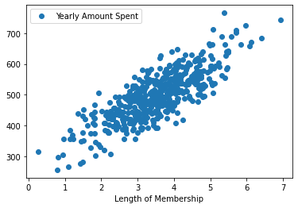

```python
ecom.plot(x="Length of Membership", y="Yearly Amount Spent", style='o')
```

```python
#advrt = pd.read_csv("advertisingB.csv") # Read the file as a .CSV assign to a dataframe
#advrt.head() # check structure
```

```python
def linearsolver(A,b):
    n = len(A)
    M = A

    i = 0
    for x in M:
     x.append(b[i])
     i += 1

    for k in range(n):
     for i in range(k,n):
       if abs(M[i][k]) > abs(M[k][k]):
          M[k], M[i] = M[i],M[k]
       else:
          pass

     for j in range(k+1,n):
         q = float(M[j][k]) / M[k][k]
         for m in range(k, n+1):
            M[j][m] -=  q * M[k][m]

    x = [0 for i in range(n)]

    x[n-1] =float(M[n-1][n])/M[n-1][n-1]
    for i in range (n-1,-1,-1):
      z = 0
      for j in range(i+1,n):
          z = z  + float(M[i][j])*x[j]
      x[i] = float(M[i][n] - z)/M[i][i]
#    print (x)
    return(x)

def matrixvectormult(amatrix,xvector,rowNumA,colNumA):
    bvector=[0.0 for i in range(rowNumA)]
    for i in range(0,rowNumA):
        for j in range(0,1):
            for k in range(0,colNumA):
                bvector[i]=bvector[i]+amatrix[i][k]*xvector[k]
    return(bvector)
```

```python
apptime=ecom["Time on App"]
seslen=ecom["Avg. Session Length"]
memlen=ecom["Length of Membership"]
webtime=ecom["Time on Website"]
moneyshot=ecom["Yearly Amount Spent"]
```

```python
colNum = 5
rowNum = len(moneyshot)
excitation_matrix = [[0 for j in range(colNum)] for i in range(rowNum)]
#result_matrix = [[0 for j in range(colNumB)] for i in range(rowNumA)]
for i in range(0,rowNum):
    excitation_matrix[i][0]=1
    excitation_matrix[i][1]=apptime[i]
    excitation_matrix[i][2]=seslen[i]
    excitation_matrix[i][3]=memlen[i]
    excitation_matrix[i][4]=webtime[i]
# observe the triple for-loop structure and the counting scheme
xt_matrix = [[0 for j in range(rowNum)] for i in range(colNum)] #transpose the matrix
for i in range(0,rowNum):
    for j in range(0,colNum):
        xt_matrix[j][i]=excitation_matrix[i][j]
rowNumA = 5 # a == transpose(excitation_matrix)
colNumA = rowNum
rowNumB = rowNum
colNumB = 5 # b == excitation_matrix
xtx_matrix = [[0 for j in range(colNumB)] for i in range(rowNumA)]
for i in range(0,rowNumA):
    for j in range(0,colNumB):
        for k in range(0,colNumA):
            xtx_matrix[i][j]=xtx_matrix[i][j]+xt_matrix[i][k]*excitation_matrix[k][j]
# observe the triple for-loop structure and the counting scheme
xty_vector = []
xty_vector = matrixvectormult(xt_matrix,moneyshot,rowNumA,colNumA)
```

```python
# copy amatrix into cmatrix
cmatrix = [[xtx_matrix[i][j] for j in range(colNumB)]for i in range(rowNumA)]
dvector = [xty_vector[i] for i in range(rowNumA)]

dvector = linearsolver(xtx_matrix,xty_vector)
```

```python
dvector
```

```
[-1051.5942552997137,
 38.709153810827736,
 25.734271084677594,
 61.57732375487672,
 0.4367388355965311]
```

```python
def moneyShot(app_time,session_length,member_length,website_time):
    moneyShot = -1051.5942552997137+38.709153810827736*app_time+25.734271084677594*session_length+61.57732375487672*member_length+0.4367388355965311*website_time
    return(moneyShot)
```

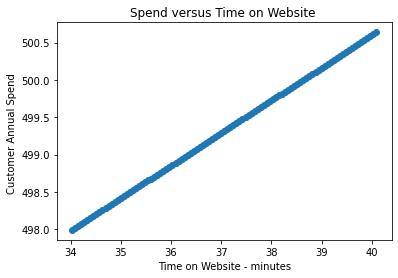

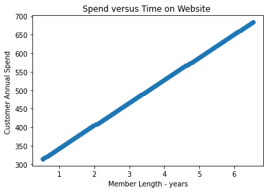

```python
predicted_spend = []
webtime = []
avgtim=ecom["Time on App"].mean()
avgses=ecom["Avg. Session Length"].mean()
avgmem=ecom["Length of Membership"].mean()
avgweb=ecom["Time on Website"].mean()
varweb=ecom["Time on Website"].std()

low = avgweb - 3*varweb
high = avgweb + 3*varweb
hilo = high - low
for i in range(101):
    wtime = low + float(i)*hilo/100.
    webtime.append(wtime)
    predicted_spend.append(moneyShot(avgtim,avgses,avgmem,wtime))

import matplotlib.pyplot
matplotlib.pyplot.scatter(webtime,predicted_spend)
matplotlib.pyplot.xlabel('Time on Website - minutes')
matplotlib.pyplot.ylabel('Customer Annual Spend ')
matplotlib.pyplot.xlabel('Time on Website - minutes')
matplotlib.pyplot.title('Spend versus Time on Website ')
matplotlib.pyplot.show()

# In class - add other components; examine apparent slope
predicted_spend = []
predictor = []
avgtim=ecom["Time on App"].mean()
avgses=ecom["Avg. Session Length"].mean()
avgmem=ecom["Length of Membership"].mean()
varmem=ecom["Length of Membership"].std()
avgweb=ecom["Time on Website"].mean()
varweb=ecom["Time on Website"].std()

low = avgmem - 3*varmem
high = avgmem + 3*varmem
hilo = high - low
for i in range(101):
    wtime = low + float(i)*hilo/100.
    predictor.append(wtime)
    predicted_spend.append(moneyShot(avgtim,avgses,wtime,avgweb))

import matplotlib.pyplot
matplotlib.pyplot.scatter(predictor,predicted_spend)
matplotlib.pyplot.xlabel('Member Length - years')
matplotlib.pyplot.ylabel('Customer Annual Spend ')
matplotlib.pyplot.title('Spend versus Time on Website ')
matplotlib.pyplot.show()
```

# Weighted Least Squares

https://scipython.com/book/chapter-8-scipy/examples/weighted-and-non-weighted-least-squares-fitting/

Consider our last lesson where we used linear algebra to construct OLS regressions

$\mathbf{X^T}\mathbf{Y}=\mathbf{X^T}\mathbf{X}\mathbf{\beta}$

If we were to insert an identy matrix (1s on the diagonal, 0s elsewhere) we could write:

$\mathbf{X^T}\mathbf{I}\mathbf{Y}=\mathbf{X^T}\mathbf{I}\mathbf{X}\mathbf{\beta}$ and there is no change.

https://www.statsmodels.org/0.6.1/examples/notebooks/generated/wls.html

```python
# copy/adapted from https://www.statsmodels.org/0.6.1/examples/notebooks/generated/wls.html


from __future__ import print_function
import numpy as np
from scipy import stats
import statsmodels.api as sm
import matplotlib.pyplot as plt
from statsmodels.sandbox.regression.predstd import wls_prediction_std
from statsmodels.iolib.table import (SimpleTable, default_txt_fmt)
np.random.seed(1024)
```

```python
nsample = 50
x = np.linspace(0, 20, nsample)
X = np.column_stack((x, (x - 5)**2))
X = sm.add_constant(X)
beta = [5., 0.5, -0.01]
sig = 0.5
w = np.ones(nsample)
w[int(nsample * 6/10):] = 3
y_true = np.dot(X, beta)
e = np.random.normal(size=nsample)
y = y_true + sig * w * e
X = X[:,[0,1]]
```

```python
mod_wls = sm.WLS(y, X, weights=1./w)
res_wls = mod_wls.fit()
print(res_wls.summary())
```

```
                            WLS Regression Results
==============================================================================
Dep. Variable:                      y   R-squared:                       0.910
Model:                            WLS   Adj. R-squared:                  0.909
Method:                 Least Squares   F-statistic:                     487.9
Date:                Tue, 06 Apr 2021   Prob (F-statistic):           8.52e-27
Time:                        15:45:25   Log-Likelihood:                -57.048
No. Observations:                  50   AIC:                             118.1
Df Residuals:                      48   BIC:                             121.9
Df Model:                           1
Covariance Type:            nonrobust
==============================================================================
                 coef    std err          t      P>|t|      [0.025      0.975]
------------------------------------------------------------------------------
const          5.2726      0.185     28.488      0.000       4.900       5.645
x1             0.4379      0.020     22.088      0.000       0.398       0.478
==============================================================================
Omnibus:                        5.040   Durbin-Watson:                   2.242
Prob(Omnibus):                  0.080   Jarque-Bera (JB):                6.431
Skew:                           0.024   Prob(JB):                       0.0401
Kurtosis:                       4.756   Cond. No.                         17.0
==============================================================================

Warnings:
[1] Standard Errors assume that the covariance matrix of the errors is correctly specified.
```

```python
res_ols = sm.OLS(y, X).fit()
print(res_ols.params)
print(res_wls.params)
```

```
[5.24256099 0.43486879]
[5.27260714 0.43794441]
```

```python
covb = res_ols.cov_params()
prediction_var = res_ols.mse_resid + (X * np.dot(covb,X.T).T).sum(1)
prediction_std = np.sqrt(prediction_var)
tppf = stats.t.ppf(0.975, res_ols.df_resid)
```

```python
prstd_ols, iv_l_ols, iv_u_ols = wls_prediction_std(res_ols)
```

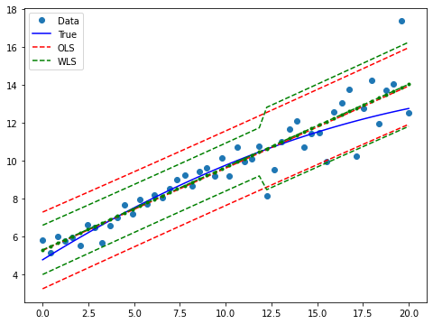

```python
prstd, iv_l, iv_u = wls_prediction_std(res_wls)

fig, ax = plt.subplots(figsize=(8,6))
ax.plot(x, y, 'o', label="Data")
ax.plot(x, y_true, 'b-', label="True")
# OLS
ax.plot(x, res_ols.fittedvalues, 'r--')
ax.plot(x, iv_u_ols, 'r--', label="OLS")
ax.plot(x, iv_l_ols, 'r--')
# WLS
ax.plot(x, res_wls.fittedvalues, 'g--.')
ax.plot(x, iv_u, 'g--', label="WLS")
ax.plot(x, iv_l, 'g--')
ax.legend(loc="best");
```

```python
resid1 = res_ols.resid[w==1.]
var1 = resid1.var(ddof=int(res_ols.df_model)+1)
resid2 = res_ols.resid[w!=1.]
var2 = resid2.var(ddof=int(res_ols.df_model)+1)
w_est = w.copy()
w_est[w!=1.] = np.sqrt(var2) / np.sqrt(var1)
res_fwls = sm.WLS(y, X, 1./w_est).fit()
print(res_fwls.summary())
```

```
                            WLS Regression Results
==============================================================================
Dep. Variable:                      y   R-squared:                       0.841
Model:                            WLS   Adj. R-squared:                  0.838
Method:                 Least Squares   F-statistic:                     253.8
Date:                Thu, 05 Nov 2020   Prob (F-statistic):           8.51e-21
Time:                        13:07:55   Log-Likelihood:                -74.830
No. Observations:                  50   AIC:                             153.7
Df Residuals:                      48   BIC:                             157.5
Df Model:                           1
Covariance Type:            nonrobust
==============================================================================
                 coef    std err          t      P>|t|      [0.025      0.975]
------------------------------------------------------------------------------
const          5.0946      0.267     19.052      0.000       4.557       5.632
x1             0.4484      0.028     15.933      0.000       0.392       0.505
==============================================================================
Omnibus:                       14.163   Durbin-Watson:                   1.358
Prob(Omnibus):                  0.001   Jarque-Bera (JB):               15.559
Skew:                          -1.145   Prob(JB):                     0.000418
Kurtosis:                       4.492   Cond. No.                         17.3
==============================================================================

Warnings:
[1] Standard Errors assume that the covariance matrix of the errors is correctly specified.
```

https://en.wikipedia.org/wiki/Weighted_least_squares

https://scipython.com/book/chapter-8-scipy/examples/weighted-and-non-weighted-least-squares-fitting/